### Mina working on question 3

[figure not shown]

Tamil Nadu

[figure not shown]

district map

Notes: - flag represents data availability (da flag) - flagsum is greater than 0 (qa flag).

3. Compare the two districts, Kallakurichi and Nagapattinam (inland and coastal, respectively), for PM2.5 measurements.

## read in data

```r
dailymeans <- read_csv("dailymeans_outdoor_HH_cleaned.csv", show_col_types = FALSE)
dailymeans <- dailymeans[, -which(names(dailymeans) == "...1")]
head(dailymeans)
```

```
## # A tibble: 6 × 10
##   date       HH     hab   district location device_type variable mean_of_medians
##   <date>     <chr>  <chr> <chr>    <chr>    <chr>       <chr>              <dbl>
## 1 2021-10-27 01001D MVL   NP       Outdoor  Atmos       pm2.5               57.8
## 2 2021-10-27 01001D MVL   NP       Outdoor  Atmos       rh                  45.6
## 3 2021-10-27 01001D MVL   NP       Outdoor  Atmos       temp                37.8
## 4 2021-10-27 01010D MVL   NP       Outdoor  Atmos       pm2.5               47.2
## 5 2021-10-27 01010D MVL   NP       Outdoor  Atmos       rh                  47.7
## 6 2021-10-27 01010D MVL   NP       Outdoor  Atmos       temp                37.7
## # ℹ 2 more variables: qa_flag <dbl>, da_flag <dbl>
```

### Data Cleaning

Here, filter out data with qa and da flags (quality and data availability flags).

```r
dailymeans <- dailymeans |>
  filter(qa_flag == 0 & da_flag == 0) |>
  select(-c(qa_flag, da_flag)) # drop these columns as no longer needed now
```

### Initial Visualization

Select PM2.5 as the variable of interest and visualize.

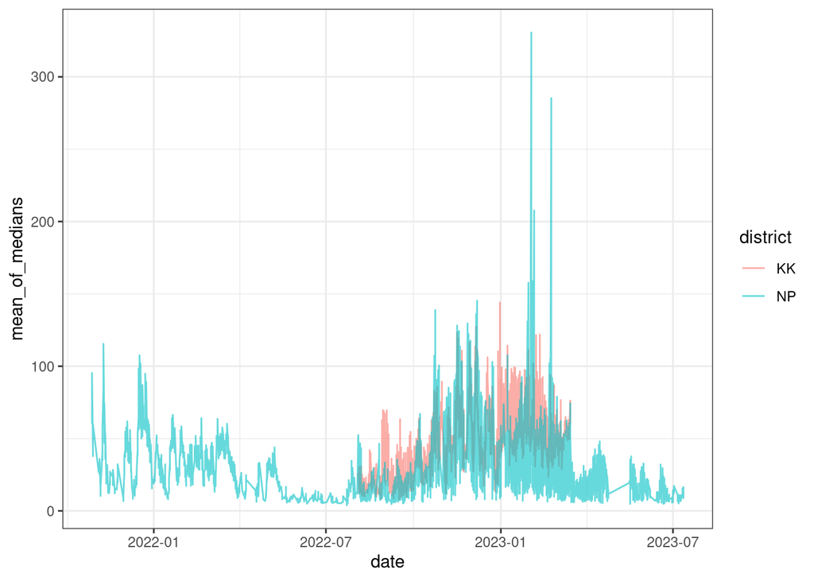

```r
# filter for pm2.5
dailymeans |>
  filter(variable == "pm2.5") |> # filter for pm2.5
  ggplot() +
  geom_line(aes(x = date, mean_of_medians, color = district), alpha = 0.6) +
  theme_bw()
```

> Initial visualization shows up that there is a gap in the time that each district has data. Next, will subset to the dates that both districts are represented for.

```r
# what date is KK first represented?
dailymeans |> filter(district == "KK") |>
  arrange((date))
```

```
## # A tibble: 11,899 × 8
##    date       HH    hab   district location device_type variable mean_of_medians
##    <date>     <chr> <chr> <chr>    <chr>    <chr>       <chr>              <dbl>
##  1 2022-08-04 1202… MLV   KK       Outdoor  Aerogram    pm2.5               26.3
##  2 2022-08-04 1202… MLV   KK       Outdoor  Aerogram    rh                  79.7
##  3 2022-08-04 1202… MLV   KK       Outdoor  Aerogram    temp                24.8
##  4 2022-08-04 1204… MLV   KK       Outdoor  Aerogram    pm2.5               24.4
##  5 2022-08-04 1204… MLV   KK       Outdoor  Aerogram    temp                24.7
##  6 2022-08-04 1204… MLV   KK       Outdoor  Aerogram    pm2.5               25.1
##  7 2022-08-04 1204… MLV   KK       Outdoor  Aerogram    rh                  75.1
##  8 2022-08-04 1204… MLV   KK       Outdoor  Aerogram    temp                25.8
##  9 2022-08-05 1200… MLV   KK       Outdoor  Aerogram    pm2.5               12.6
## 10 2022-08-05 1200… MLV   KK       Outdoor  Aerogram    rh                  84.5
## # ℹ 11,889 more rows
```

```r
# what does KK data go until?
dailymeans |> filter(district == "KK") |>
  arrange(desc(date))
```

```
## # A tibble: 11,899 × 8
##    date       HH    hab   district location device_type variable mean_of_medians
##    <date>     <chr> <chr> <chr>    <chr>    <chr>       <chr>              <dbl>
##  1 2023-03-15 1101… MLK   KK       Outdoor  Aerogram    pm2.5               76.2
##  2 2023-03-15 1101… MLK   KK       Outdoor  Aerogram    rh                  57.2
##  3 2023-03-15 1101… MLK   KK       Outdoor  Aerogram    temp                32.4
##  4 2023-03-15 1101… MLK   KK       Outdoor  Aerogram    pm2.5               60.5
##  5 2023-03-15 1101… MLK   KK       Outdoor  Aerogram    rh                  59.9
##  6 2023-03-15 1101… MLK   KK       Outdoor  Aerogram    temp                32.2
##  7 2023-03-15 1101… MLK   KK       Outdoor  Aerogram    pm2.5               69.1
##  8 2023-03-15 1101… MLK   KK       Outdoor  Aerogram    rh                  53.2
##  9 2023-03-15 1101… MLK   KK       Outdoor  Aerogram    temp                31.8
## 10 2023-03-15 1101… MLK   KK       Outdoor  Aerogram    pm2.5               63.6
## # ℹ 11,889 more rows
```

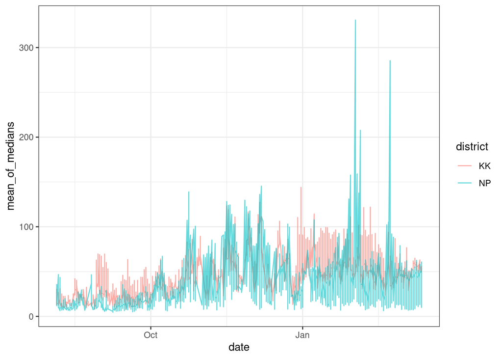

```r
# change x axis

# filter for dates that KK is represented in
filtered_dates <- dailymeans |>
  filter(date > "2022-08-04" & date < "2023-03-15") |>
  filter(variable == "pm2.5")  # filter for pm2.5

ggplot(data = filtered_dates) +
  geom_line(aes(x = date, mean_of_medians, color = district), alpha = 0.6) +
  theme_bw()
```

> Nice, this is a better visualization. Let’s improve the plot, add labels, and see what they look like on separate plots.

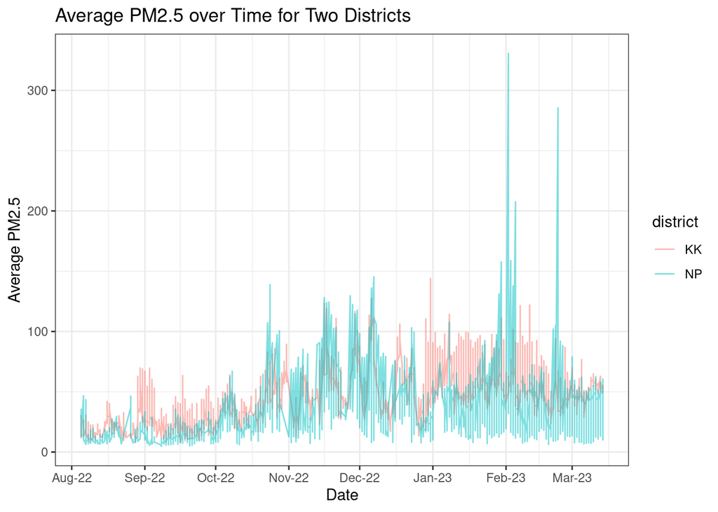

```r
filtered_dates |>
  ggplot() +
  geom_line(aes(x = date, mean_of_medians, color = district), alpha = 0.5) +
  labs(title = "Average PM2.5 over Time for Two Districts", x = "Date", y = "Average PM2.5") +
  scale_x_date(date_breaks = "1 month" , date_labels = "%b-%y") +
  theme_bw()
```

> Now we can see how the two districts compare. Let’s visualize them with a facet wrap next.

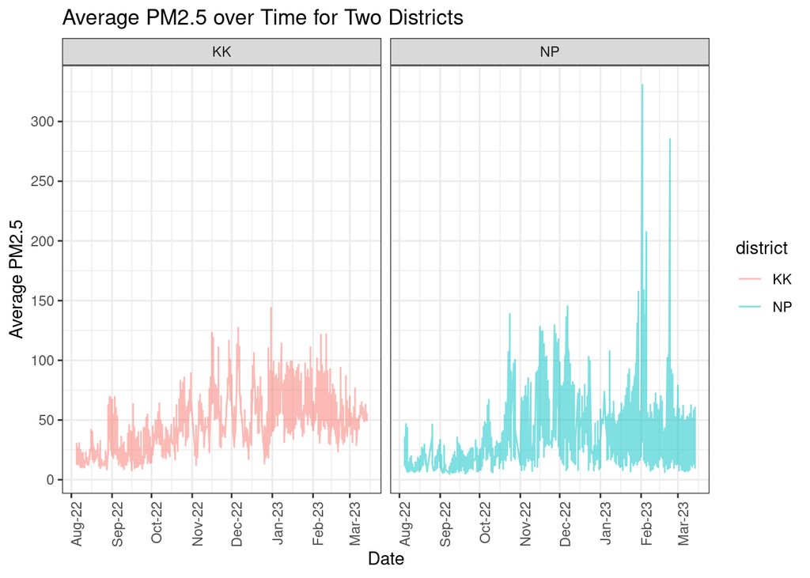

```r
filtered_dates |>
  ggplot() +
  geom_line(aes(x = date, mean_of_medians, color = district), alpha = 0.5) +
  labs(title = "Average PM2.5 over Time for Two Districts", x = "Date", y = "Average PM2.5") +
  theme_bw() +
  scale_y_continuous(breaks = seq(0, 400, 50)) +
  scale_x_date(date_breaks = "1 month" , date_labels = "%b-%y") +
  facet_wrap(~district, ncol = 2) +
  theme(axis.text.x = element_text(angle = 90, hjust = 1))
```

Here, create a table with an average PM2.5 summary per district, along with standard error.

```r
tab <- filtered_dates |>
  group_by(district) |>
  summarize(average = mean(mean_of_medians),
            se = sd(mean_of_medians) / sqrt(n()))
tab
```

```
## # A tibble: 2 × 3
##   district average    se
##   <chr>      <dbl> <dbl>
## 1 KK          45.0 0.325
## 2 NP          33.7 0.391
```

Visualize the summarized values as a bar plot.

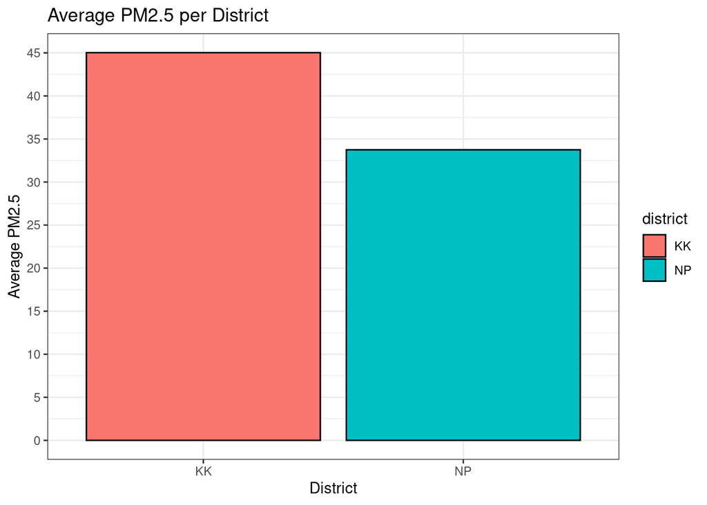

```r
tab |>
  ggplot() +
  geom_col(aes(x = district, y = average, fill = district), color = "black") +
  scale_y_continuous(breaks = seq(0, 50, 5)) +
  theme_bw() +
  labs(title = "Average PM2.5 per District", x = "District", y = "Average PM2.5")
```

Facet wrap the two plots.

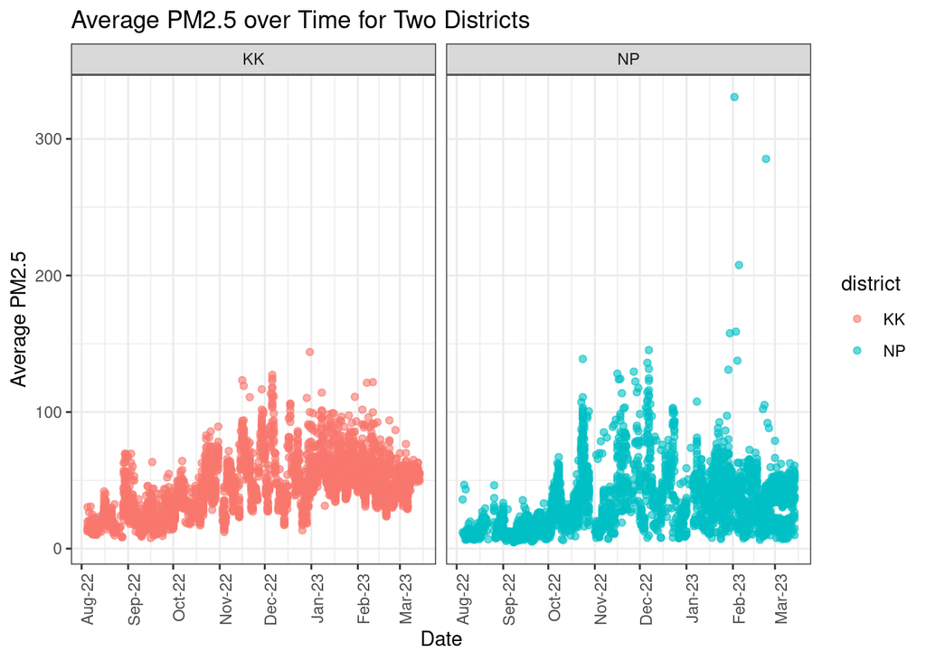

```r
filtered_dates |>
  ggplot() +
  geom_point(aes(x = date, mean_of_medians, color = district), alpha = 0.6) +
  labs(title = "Average PM2.5 over Time for Two Districts", x = "Date", y = "Average PM2.5") +
  theme_bw() +
  scale_x_date(date_breaks = "1 month" , date_labels = "%b-%y") +
  facet_wrap(~district, ncol = 2) +
  theme(axis.text.x = element_text(angle = 90, hjust = 1))
```

Generate a density plot for the averages of PM2.5.

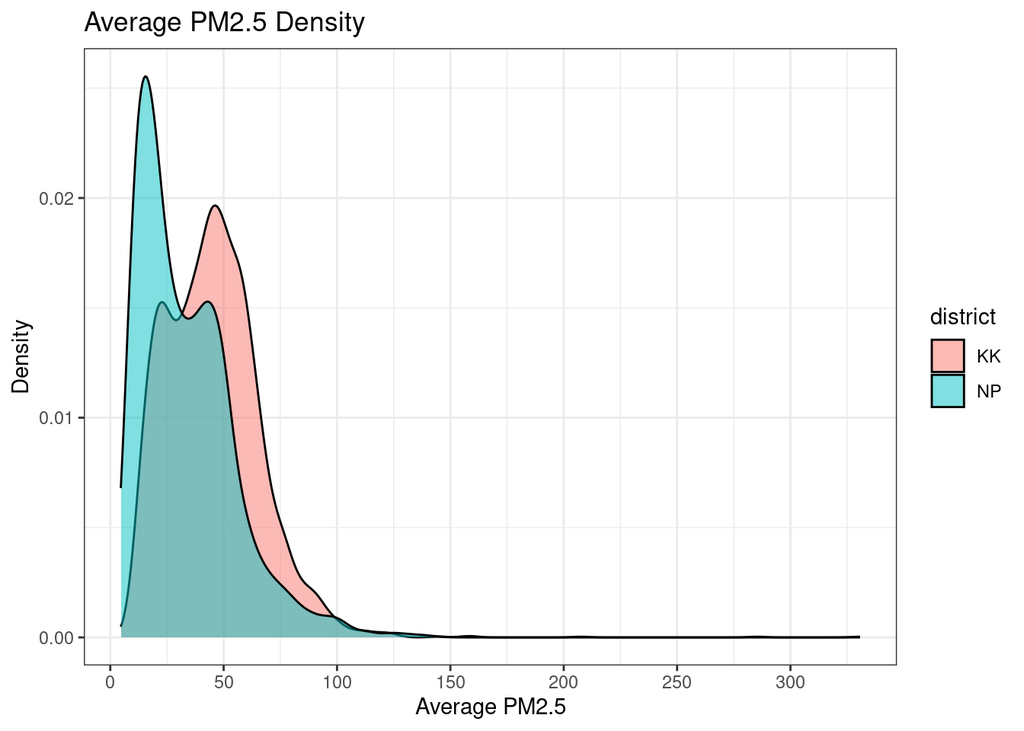

```r
filtered_dates |>
  ggplot() +
  geom_density(aes(x = mean_of_medians, fill = district), alpha = 0.5) +
  labs(title = "Average PM2.5 Density", x = "Average PM2.5", y = "Density") +
  scale_x_continuous(breaks = seq(0, 400, 50)) +
  theme_bw()
```

### Analysis Results

> We see based on the results on the analysis that Kallakurichi (KK) has a higher average PM2.5, while Nagapattinam (NP) has lower average PM2.5. Referencing the map again, we can see that Kallakurichi is inland, and Nagapattinam is coastally located. Thus, one explanation for the differences between the PM2.5 for the two districts is the potential coastal influence of NP. The influx of wind from the sea can blow away particulate matter, reducing the average PM2.5 ratings picked up by the sensors. KK is quite far inland, so it wouldn’t experience the same winds from the sea, which may explain why it has higher PM2.5 sensor readings.